# Event study design: How normalisation affects estimation and inference

Miller (2023, p.220) also notes that trends may embed quadratic trends in `et`:

> *Finally, if we are working with a timing-based data structure, controlling for trends has potential to create surprising and severe problems. Adding linear trend controls (and the required additional parameter restriction) can induce quadratic trends into our estimated event study coefficients. This arises from a subtle way in which the event dummies are collinear with the other variables in the model (as illustrated in online Appendix F.2)*

Impacts on divorce and marriage rates: State specific trends

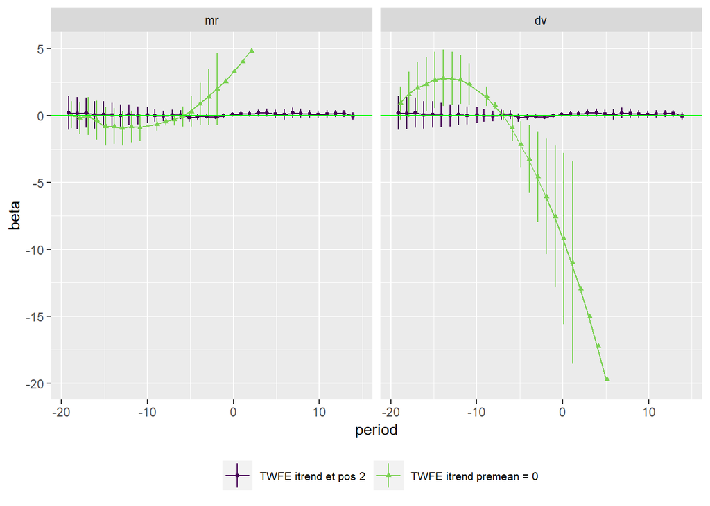

To dig into what is going on, we will:

- Restrict et to be between -15 and 10 (or 11) because there are fewer observations outside this window (see the below table).
- Keep only a few states and see.

```r
options(width = 120)
Ci <- NULL
for (ob in c("mr", "dv")) {
  obj1 = copy(get(ob))
  #### Restrict: -15 <= et <= 10
  obj1[, time := factor(time,
      levels = c(1988, levels(time)[!(levels(time) %in% c(1988, 1959:1961))],
        1961:1959))]
  obj1[, et := as.numeric(as.character(et))]
  #### et < -15 | et > 10 ==> -1, so it does not directly
  #### affect delta (et estimates) once we impose \delta_{-1}=0.
  obj1[et < -15 | et > 10, et := -1L]
  obj1[, et := factor(et)]
  obj1[, et := factor(et, levels = c(-1, levels(et)[!(levels(et) %in% c(-1))]))]
  obj1 <- obj1[grepl("^[A-Z]", StateName) & as.numeric(as.character(time)) > 1960, ]
  #### r10bb: TWFE with et window restriction
  r10bb <- lm(v ~ -1+StateName+time+et,
    data = obj1[as.numeric(as.character(time)) > 1960, ])
  #### r22: TWFE with indiv trends and et window restriction, small samples
  r22s <- lm(v ~ -1+trend*StateName+time+et, data = obj1)
  #### Explicitly drop etN16, etN17, ..., et11, et12, and allow etN1 to be kept
  etdumpre <- makeDummyFromFactor(factor(obj1[, et]),
    nameprefix = "et", reference = NULL)
  setnames(etdumpre, grepout("-", colnames(etdumpre)),
    gsub("-", "N", grepout("-", colnames(etdumpre))))
  #### Drop et < -15 | et > 10 terms
  etdumpre[, grepout("N2.|N1[6-9]|et1[1-9]", colnames(etdumpre)) := NULL]
  ettermspre <- paste(colnames(etdumpre), collapse = "+")
  #### Explicitly drop et < -15 | et > 10 terms and drop etN1
  etdumpre[, etN1 := NULL]
  ettermspre <- paste(colnames(etdumpre), collapse = "+")
  obj3 <- data.table(obj1, etdumpre)
  form2 <- paste0("v ~ -1+trend*StateName+time+", ettermspre)
  #### r22ee: TWFE with indiv trends, et window restriction, dropping N1
  #### TWFE itrend no N1 N15P10
  r22ees <- lm(as.formula(form2), data = obj3)
  #### Preperiod = 0 restriction on the data matrix.
  etdumpre <- makeDummyFromFactor(factor(obj1[, et]),
    nameprefix = "et", reference = NULL)
  setnames(etdumpre, grepout("-", colnames(etdumpre)),
    gsub("-", "N", grepout("-", colnames(etdumpre))))
  etdumpre[, grepout("N2.|N1[6-9]|et1[1-9]", colnames(etdumpre)) := NULL]
  negtime <- grepout("N", colnames(etdumpre))
  etdumpre[, (negtime) := lapply(.SD, function(x) x-etN10), .SDcols = negtime]
  etdumpre[, etN10 := NULL]
  #### Drop etN2X - etN20 from formula.
  #### This is already dropped so no change is made here.
  ettermspre <- paste(colnames(etdumpre), collapse = "+")
  ettermspre2 <- gsub("etN2..*etN20\\+", "", ettermspre)
  obj3 <- data.table(obj1, etdumpre)
  form2 <- paste0("v ~ -1+trend*StateName+time+", ettermspre2)
  #### r32s: state individual trends, time, et with preperiod = 0
  r32s <- lm(as.formula(form2), data = obj3)
  #### Add "TWFE itrend N15P10" to forder, paste N15P10 to r22
  regob <- paste0("r", c("10a", "10bb", "10c",
      "22a", "22", "22c", "31", "32s", "33", #### 32s is substituted to 32
       "22ees")) #### this is added
  forder2 <- c(forder, "TWFE itrend N15P10", "TWFE itrend no N1 N15P10")
  forder2 <- gsub("i?trend et pos 2", "itrend et pos 2 N15P10", forder2)
  forder2 <- gsub("E et pos 2", "E et pos 2 N15P10", forder2)
  forder2 <- gsub(" trend premean = 0", " itrend premean = 0 N15P10", forder2)
  Ci0 <- NULL
  for (i in 1:length(regob)) {
    rr <- get(regob[i])
    clus <- data.table(rr$model)[, StateName]
    rrc <- clx(rr, cluster = clus, returnV = T)
    clxci <- data.table(cbind(Coef = rownames(rrc$ci), rrc$est, rrc$ci))
    if (i < 7) clxci <- rbind(clxci, t(c(-1, 0, rep(NA, 5))), use.names = F)
    clxci[, FormulaOrder := forder2[i]]
    clxci[, spec := regob[i]]
    Ci0 <- rbind(Ci0, clxci)
  }
  Ci0[, period := gsub("et", "", Coef)]
  Ci0 <- Ci0[grepl("^.?\\d|tre", period), ]
  Ci0[, period := gsub("N", "-", period)]
  Ci0[, period := as.numeric(period)]
  Ci0[, outcome := ob]
  Ci0[, FormulaOrder := factor(FormulaOrder, levels = forder2)]
  setnames(Ci0, c("Estimate", "2.5 %", "97.5 %"), c("beta", "CI_L", "CI_U"))
  Ci <- rbindlist(list(Ci, Ci0), fill = T)
  setcolorder(Ci, c("Coef", "beta", "Std. Error", "t value",
    "Pr(>|t|)", "CI_L", "CI_U", "period"))
  numcols <- c("beta", "CI_L", "CI_U", "period")
  Ci[, (numcols) := lapply(.SD, as.numeric), .SDcols = numcols]
  strcols <- colnames(Ci)[!(colnames(Ci) %in% numcols)]
  Ci[, (strcols) := lapply(.SD, factor), .SDcols = strcols]
}
Ci[grepl("s$", spec) & (abs(period) <= 3 | grepl("trend$", Coef)),
  c("outcome", "Coef", "beta", "Pr(>|t|)", "spec", "FormulaOrder")]
```

```
    outcome  Coef        beta             Pr(>|t|)   spec                   FormulaOrder
 1:      mr trend  0.21817570  9.6624619428244e-89   r32s TWFE itrend premean = 0 N15P10
 2:      mr  etN1  0.09107211    0.743252307349297   r32s TWFE itrend premean = 0 N15P10
 3:      mr  etN3  0.01766871    0.926619850156344   r32s TWFE itrend premean = 0 N15P10
 4:      mr  etN2  0.07287639     0.76784543765025   r32s TWFE itrend premean = 0 N15P10
 5:      mr   et0  0.14294933    0.678906830554418   r32s TWFE itrend premean = 0 N15P10
 6:      mr   et1  0.19091388    0.637144841271113   r32s TWFE itrend premean = 0 N15P10
 7:      mr   et2  0.23560346    0.618110547043362   r32s TWFE itrend premean = 0 N15P10
 8:      mr   et3  0.25970411    0.587705801103398   r32s TWFE itrend premean = 0 N15P10
 9:      mr trend  0.21817570 9.66246194282577e-89 r22ees             TWFE itrend N15P10
10:      mr  etN3 -0.07340340    0.675549267865677 r22ees             TWFE itrend N15P10
11:      mr  etN2 -0.01819572    0.877211590941907 r22ees             TWFE itrend N15P10
12:      mr   et0  0.05187722    0.569473075923662 r22ees             TWFE itrend N15P10
13:      mr   et1  0.09984177     0.50085034303557 r22ees             TWFE itrend N15P10
14:      mr   et2  0.14453135    0.505841258958236 r22ees             TWFE itrend N15P10
```

[output cut: 17 more lines]

Impacts on divorce and marriage rates: State specific trends, et window N15-10, small sample

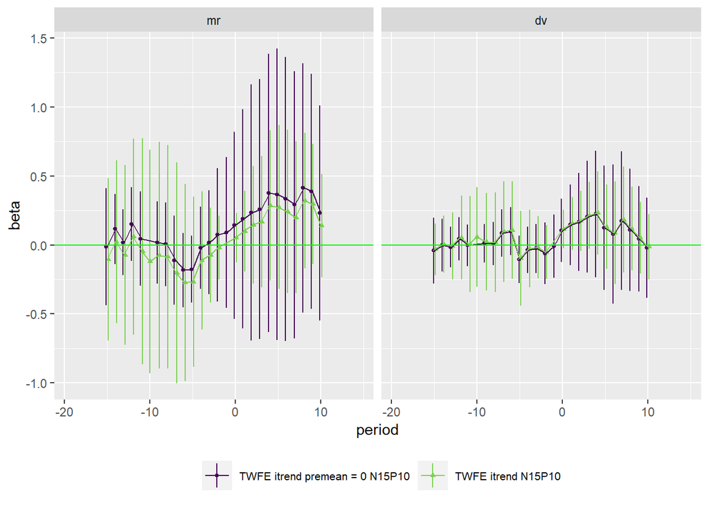

- Under this window restriction, estimates under $\bar{\delta}_{s<0}=0$ restriction are not diverging.
- Again, in the neighbourhood of when $\delta_{t}=0$ is imposed (-10 and -1), SEs are smaller.
- Why are $\bar{R}^{2}$’s so high?

```r
#### Restrict: -15 <= et <= 10
obj = copy(dv)
table(obj[as.numeric(as.character(time)) > 1960, et])
```

```
 -1 -24 -23 -22 -21 -20 -19 -18 -17 -16 -15 -14 -13 -12 -11 -10  -9  -8  -7  -6  -5  -4  -3  -2   0   1   2   3   4   5
 34   0   0   1   1   2   3   6   9  14  24  32  33  34  34  34  34  34  34  34  34  34  34  34  34  34  34  34  34  34
  6   7   8   9  10  11  12  13  14  15
 33  33  32  31  28  25  20  10   2   1
```